# s01 — baseline vs. iterative mapping (chr19, SNP-only)

gwct

10/28/2026 12:12 EDT

```r
knitr::opts_chunk$set(echo = TRUE, warning = FALSE, message = FALSE, fig.align = "center")
library(ggplot2); library(dplyr); library(tidyr); library(readr)
source("analyses/lib/design.r")   # bartheme(), corecol(); knit from the project root
```

**Provenance**

- **Rendered from commit** `5a622987dc70` (branch `mason2-sims`) on 2026-10-28 12:12
- **This notebook:** notebook as committed
- **Analysis code:** no uncommitted edits under `analyses/`
- Each data file’s producing script and command: the section’s `MANIFEST.yaml`

# 1 Question & design

**Does iterative (pseudo-it) mapping recover more true divergence than single-shot mapping, and does that depend on the variant caller?** A diverged sample is simulated against the mm39 reference, mapped back, and variant-called; reference bias is the true divergence that gets lost. Iterative mapping remaps to a consensus that absorbs the recovered divergence, lowering the *effective* divergence each round.

Everything below is **chr19, SNP-only, 30×**, produced by `workflow.smk` (divergence recovery), `het_recovery.smk` (het), and `read_classification.smk` (read placement), all driven by `config/config.yaml` and launched with the `run_*.sh` orchestrators.

```r
# --- truth check (Methods): stop rather than score recall against SNPs the reads do not carry ---
tc <- read_csv("analyses/s01-baseline-iterative/results/effective-truth/phantom-by-divergence.csv", col_types = cols())
stopifnot(sum(tc$n_phantom_div + tc$n_phantom_het) == 0)

# --- divergence recovery (from the consensus-vs-reference diff) ---
d <- read_csv("analyses/s01-baseline-iterative/results/s01-base-iterative-summary.csv") %>%
  filter(divergence > 0) %>%                       # no divergence sites at D=0
  mutate(recall    = div_tp / n_truth_div,
         precision = ifelse(n_called_snp > 0, 1 - fp / n_called_snp, NA),
         caller    = factor(caller, levels = c("gatk", "bcftools", "freebayes")),
         iteration = factor(iteration))
agg <- d %>% group_by(caller, divergence, iteration) %>%
  summarize(recall_m = mean(recall), recall_sd = sd(recall),
            prec_m = mean(precision), prec_sd = sd(precision), .groups = "drop")
n_iter <- max(as.integer(as.character(d$iteration)))
cols   <- corecol(pal = "wilke", numcol = n_iter)

# --- het recovery + fate bands (from the raw per-iteration caller VCF) ---
het <- read_csv("analyses/s01-baseline-iterative/results/s01-base-het-recovery-by-iter.csv") %>%
  mutate(caller = factor(caller, levels = c("gatk", "bcftools", "freebayes")),
         iteration = factor(iteration),
         het_recall = het_tp / n_truth_het)   # D=0 KEPT: het recall at D=0 = the germline baseline
hets <- het %>% group_by(caller, divergence, iteration) %>%
  summarize(m = mean(het_recall), s = sd(het_recall), .groups = "drop")

# --- read placement ---
rc <- read_csv("analyses/s01-baseline-iterative/results/s01-base-readclass-by-iter.csv") %>%
  mutate(caller = factor(caller, levels = c("gatk", "bcftools", "freebayes")),
         iteration = factor(iteration))   # D=0 KEPT: near-all-exact mapping baseline

# --- fate of divergent sites (cumulative-correct) ---
# Recovered comes from the CONSENSUS (d$div_tp), because a site recovered in one round is
# baked into the consensus and no longer re-called the next -- so the raw caller VCF would
# wrongly show it migrating back to "lost". The het/other bands (sites the caller calls
# 0/1 or wrong-allele, hence NOT baked into the hom consensus) come from the caller VCF;
# lost-to-reference is the remainder.
fate <- inner_join(
    d   %>% select(caller, divergence, seed, iteration, n_truth_div, rec = div_tp),
    het %>% select(caller, divergence, seed, iteration, div_het, div_other),
    by = c("caller", "divergence", "seed", "iteration")) %>%
  mutate(lost = pmax(n_truth_div - rec - div_het - div_other, 0)) %>%
  group_by(caller, divergence, iteration) %>%
  summarize(Recovered           = mean(rec / n_truth_div),
            `Called het`        = mean(div_het / n_truth_div),
            `Lost to reference` = mean(lost / n_truth_div),
            Other               = mean(div_other / n_truth_div), .groups = "drop") %>%
  pivot_longer(-c(caller, divergence, iteration), names_to = "fate", values_to = "prop") %>%
  mutate(fate = factor(fate, levels = c("Recovered", "Called het",
                                        "Lost to reference", "Other")))

small_legend <- theme(legend.position = "bottom",
                      legend.text = element_text(size = 8),
                      legend.title = element_blank(),
                      legend.key.size = unit(0.40, "cm"))
```

# 2 Read classification

The mapping-side view: where did each read actually land relative to where it was simulated from? Each stacked bar is the composition of read placements at one iteration (exact / shifted / soft-clipped / span-off / mismapped / diff-chr / unmapped), for every caller (rows) and divergence (columns). Iteration 1 maps to the reference and so is caller-independent; later iterations map to each caller’s own consensus. `span_off` = correct start, but the read’s reference footprint is >10 bp off its true one; ≤0.004% of reads here (a class of its own only since the 2026-10-27 tables; before, these reads counted as exact).

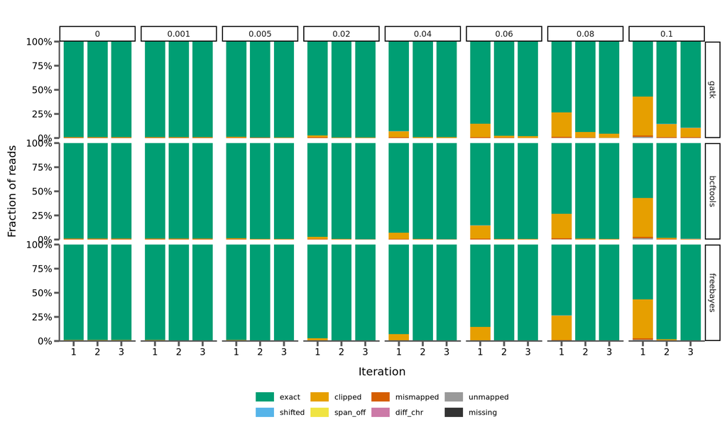

```r
classes <- c("exact", "shifted", "clipped", "span_off", "mismapped", "diff_chr", "unmapped", "missing")
class_cols <- c(exact = "#009E73", shifted = "#56B4E9", clipped = "#E69F00", span_off = "#F0E442",
                mismapped = "#D55E00", diff_chr = "#CC79A7",
                unmapped = "#999999", missing = "#333333")
comp <- rc %>% group_by(caller, divergence, iteration) %>%
  summarize(across(all_of(paste0(classes, "_prop")), mean), .groups = "drop") %>%
  pivot_longer(-c(caller, divergence, iteration), names_to = "class", values_to = "prop") %>%
  mutate(class = factor(sub("_prop", "", class), levels = classes))

ggplot(comp, aes(x = iteration, y = prop, fill = class)) +
  geom_col(width = 0.85) +
  facet_grid(caller ~ divergence) +
  scale_y_continuous(labels = scales::percent, expand = c(0, 0)) +
  scale_fill_manual(values = class_cols) +
  xlab("Iteration") + ylab("Fraction of reads") +
  bartheme() + small_legend
```

**Interpretation.** Read the **iter1 bars across the three caller rows — they are identical**: single-shot mapping is caller-independent (everyone maps to the reference), and at D=0.10 only ~57% of reads are exact, ~40% soft-clipped. That is the key control — the reads are placed the *same way* for every caller at iter1, yet gatk recovers far fewer SNPs (§3) — so gatk’s single-shot deficit is its reference-anchored reassembler, not a mapping/clipping artifact. From iter2 the rows separate: bcftools/freebayes recover ~all divergence at iter1, so their consensus is near-complete and reads map almost perfectly by iter2; gatk’s consensus improves gradually, so its soft-clip band shrinks gradually (~40%→10% at D=0.10). Mapping quality is *downstream* of caller recovery (recover → consensus → better mapping → recover more), and the soft-clipped bases are retained in the BAM and used by gatk anyway — so this is a readout of falling effective divergence, not evidence removed from the caller.

# 3 SNP recovery

The homozygous-divergence result — the core reference-bias question — from four angles: the fate of every divergent site, the recovered counts, recall/precision, and how the iteration benefit differs by caller.

## 3.1 Fate of divergent sites per iteration

Every true divergent site is homozygous-alternate and *should* be recovered as such; these stacked bars show what actually becomes of it at each iteration — the variant-calling analogue of the read-placement composition above. **Recovered** = the site is in the consensus (cumulative); **Called het** / **Other** = the raw caller VCF calls it `0/1` or with the wrong allele (so it is not baked into the hom consensus); **Lost to reference** = the remainder (the sample looks like the reference — reference bias itself).

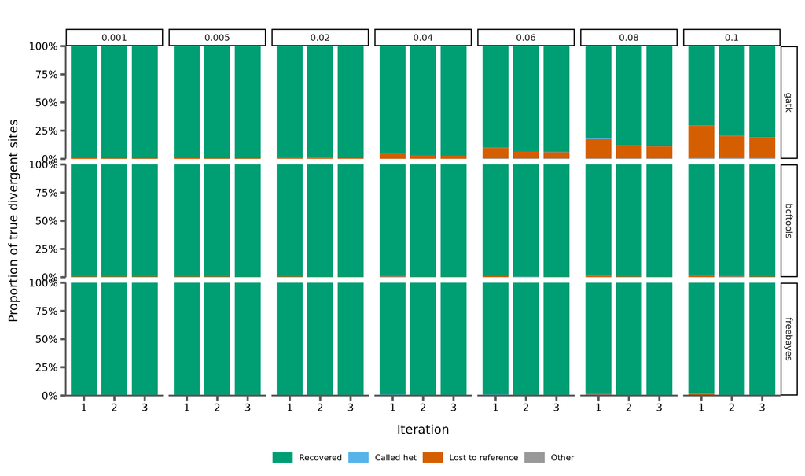

```r
fate_cols <- c("Recovered" = "#009e73", "Called het" = "#56b4e9",
               "Lost to reference" = "#d55e00", "Other" = "#999999")
ggplot(fate, aes(x = iteration, y = prop, fill = fate)) +
  geom_col(width = 0.85) +
  facet_grid(caller ~ divergence) +
  scale_y_continuous(labels = scales::percent, expand = c(0, 0)) +
  scale_fill_manual(values = fate_cols) +
  xlab("Iteration") + ylab("Proportion of true divergent sites") +
  bartheme() + small_legend
```

**Interpretation.** The orange **Lost to reference** band *is* reference bias, and it shrinks every iteration — most dramatically for gatk at high divergence (28% → 18% lost at D=0.10). The **Called het** band (a divergent site only partly rescued — one allele’s worth of reads surviving) stays thin throughout (~0.5%). bcftools/freebayes are almost fully green from iteration 1; gatk starts with a large lost band that iteration steadily eats into. This is the recall story below shown as a complete accounting of where every divergent site goes.

## 3.2 Recovered SNP counts

True divergent SNPs recovered, shown as **count (% of truth, +new)**, by caller and divergence for each iteration (means over the 3 seeds). **+new** = additional true SNPs recovered vs. the previous iteration (blank for iter1, the single-shot baseline); `truth` = total divergent sites simulated. Rows are grouped by caller.

```r
library(kableExtra)
fmt <- function(x) formatC(round(x), format = "d", big.mark = ",")
cells <- d %>%
  group_by(caller, divergence, iteration) %>%
  summarize(recovered = mean(div_tp),
            recall    = mean(div_tp / n_truth_div), .groups = "drop") %>%
  arrange(caller, divergence, iteration) %>%
  group_by(caller, divergence) %>%
  mutate(gained = recovered - lag(recovered)) %>%   # new SNPs vs previous iteration
  ungroup() %>%
  mutate(cell = ifelse(is.na(gained),
                       sprintf("%s (%.1f%%)", fmt(recovered), 100 * recall),
                       sprintf("%s (%.1f%%, +%s)", fmt(recovered), 100 * recall, fmt(gained))),
         iteration = paste0("iter", iteration)) %>%
  select(caller, divergence, iteration, cell) %>%
  pivot_wider(names_from = iteration, values_from = cell)

truth_col <- d %>% group_by(caller, divergence) %>%
  summarize(truth = formatC(round(mean(n_truth_div)), format = "d", big.mark = ","),
            .groups = "drop")
tab <- left_join(truth_col, cells, by = c("caller", "divergence")) %>%
  arrange(caller, divergence)

grp  <- tab %>% count(caller)
disp <- tab %>% select(-caller)
kbl <- knitr::kable(
    disp, align = "r",
    col.names = c("divergence", "truth", paste0("iter", seq_len(n_iter))),
    caption = "True divergent SNPs recovered as count (% of truth), mean over seeds.") %>%
  kable_styling(bootstrap_options = c("striped", "hover", "condensed"),
                full_width = FALSE, position = "center")
start <- 1
for (i in seq_len(nrow(grp))) {
  kbl   <- kbl %>% pack_rows(as.character(grp$caller[i]), start, start + grp$n[i] - 1)
  start <- start + grp$n[i]
}
kbl
```

True divergent SNPs recovered as count (% of truth), mean over seeds.

| divergence | truth | iter1 | iter2 | iter3 |
| --- | --- | --- | --- | --- |
| **gatk** |  |  |  |  |
| 0.001 | 61,420 | 60,960 (99.3%) | 61,017 (99.3%, +57) | 61,030 (99.4%, +13) |
| 0.005 | 307,100 | 304,612 (99.2%) | 305,375 (99.4%, +762) | 305,645 (99.5%, +271) |
| 0.020 | 1,228,400 | 1,204,062 (98.0%) | 1,214,739 (98.9%, +10,677) | 1,216,987 (99.1%, +2,248) |
| 0.040 | 2,456,800 | 2,328,514 (94.8%) | 2,375,821 (96.7%, +47,306) | 2,383,892 (97.0%, +8,072) |
| 0.060 | 3,685,200 | 3,317,825 (90.0%) | 3,436,288 (93.2%, +118,463) | 3,455,271 (93.8%, +18,983) |
| 0.080 | 4,913,600 | 4,031,649 (82.1%) | 4,314,914 (87.8%, +283,264) | 4,358,790 (88.7%, +43,876) |
| 0.100 | 6,142,000 | 4,323,047 (70.4%) | 4,883,469 (79.5%, +560,422) | 4,977,584 (81.0%, +94,115) |
| **bcftools** |  |  |  |  |
| 0.001 | 61,420 | 61,010 (99.3%) | 61,071 (99.4%, +61) | 61,088 (99.5%, +17) |
| 0.005 | 307,100 | 305,046 (99.3%) | 305,737 (99.6%, +691) | 306,027 (99.7%, +290) |
| 0.020 | 1,228,400 | 1,219,492 (99.3%) | 1,223,862 (99.6%, +4,370) | 1,225,714 (99.8%, +1,852) |
| 0.040 | 2,456,800 | 2,437,164 (99.2%) | 2,447,364 (99.6%, +10,200) | 2,451,293 (99.8%, +3,929) |
| 0.060 | 3,685,200 | 3,650,876 (99.1%) | 3,668,717 (99.6%, +17,841) | 3,674,732 (99.7%, +6,016) |
| 0.080 | 4,913,600 | 4,853,842 (98.8%) | 4,885,985 (99.4%, +32,143) | 4,894,973 (99.6%, +8,989) |
| 0.100 | 6,142,000 | 6,001,274 (97.7%) | 6,091,846 (99.2%, +90,572) | 6,105,752 (99.4%, +13,906) |
| **freebayes** |  |  |  |  |
| 0.001 | 61,420 | 60,990 (99.3%) | 61,047 (99.4%, +58) | 61,062 (99.4%, +15) |
| 0.005 | 307,100 | 304,956 (99.3%) | 305,633 (99.5%, +676) | 305,907 (99.6%, +274) |
| 0.020 | 1,228,400 | 1,219,094 (99.2%) | 1,223,515 (99.6%, +4,421) | 1,225,418 (99.8%, +1,903) |
| 0.040 | 2,456,800 | 2,436,585 (99.2%) | 2,446,878 (99.6%, +10,293) | 2,450,927 (99.8%, +4,049) |
| 0.060 | 3,685,200 | 3,650,907 (99.1%) | 3,668,761 (99.6%, +17,854) | 3,674,927 (99.7%, +6,166) |
| 0.080 | 4,913,600 | 4,855,887 (98.8%) | 4,887,649 (99.5%, +31,762) | 4,896,620 (99.7%, +8,971) |
| 0.100 | 6,142,000 | 6,001,333 (97.7%) | 6,097,030 (99.3%, +95,697) | 6,110,699 (99.5%, +13,669) |

## 3.3 Precision and recall

Recall (recovered / truth) and precision (of the consensus SNP set vs truth), by caller. At each divergence the grey connector spans the iterations, so its length is the iteration gain; error bars are ±1 SD over the 3 seeds.

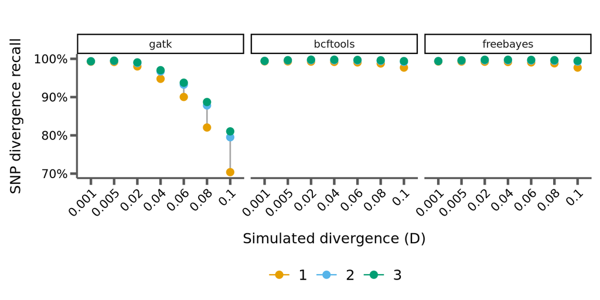

```r
ggplot(agg, aes(x = factor(divergence), y = recall_m, color = iteration)) +
  geom_line(aes(group = divergence), color = "grey65", size = 0.6) +
  geom_errorbar(aes(ymin = recall_m - recall_sd, ymax = recall_m + recall_sd), width = 0.0015) +
  geom_point(size = 2.6) +
  facet_wrap(~caller) +
  scale_x_discrete(guide = guide_axis(angle = 45)) +
  scale_y_continuous(labels = scales::percent) +
  scale_color_manual(values = cols, name = "Iteration") +
  xlab("Simulated divergence (D)") + ylab("SNP divergence recall") +
  bartheme() + theme(legend.position = "bottom")
```

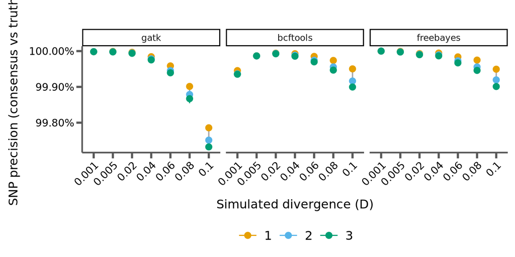

```r
ggplot(agg, aes(x = factor(divergence), y = prec_m, color = iteration)) +
  geom_line(aes(group = divergence), color = "grey65", size = 0.6) +
  geom_errorbar(aes(ymin = prec_m - prec_sd, ymax = prec_m + prec_sd), width = 0.0015) +
  geom_point(size = 2.6) +
  facet_wrap(~caller) +
  scale_x_discrete(guide = guide_axis(angle = 45)) +
  scale_y_continuous(labels = scales::percent) +
  scale_color_manual(values = cols, name = "Iteration") +
  xlab("Simulated divergence (D)") + ylab("SNP precision (consensus vs truth)") +
  bartheme() + theme(legend.position = "bottom")
```

**Interpretation.** Recall rises every iteration and converges by ~3 rounds; the effect is tiny for **bcftools / freebayes** (already ~99% — little headroom) and large for **gatk**, whose single-shot recall collapses at high divergence but is substantially rescued. Error bars are <0.1 pt everywhere (aggregate recall over chr19’s millions of sites is near-deterministic — the near-zero seed variance is itself a result). Precision confirms the recall gains are not bought with false positives.

## 3.4 Variant caller comparison

Where iteration helps most: the recall improvement from single-shot (iter1) to the last iteration, by caller and divergence.

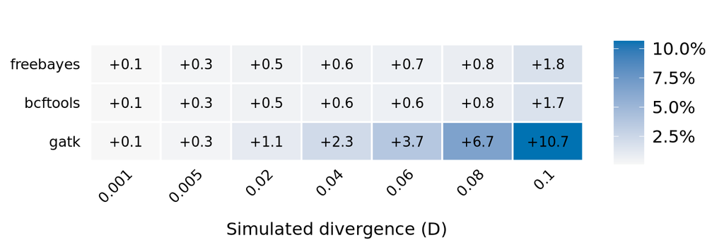

```r
gain <- agg %>%
  filter(iteration %in% c("1", as.character(n_iter))) %>%
  select(caller, divergence, iteration, recall_m) %>%
  pivot_wider(names_from = iteration, values_from = recall_m) %>%
  mutate(gain = .data[[as.character(n_iter)]] - .data[["1"]])

ggplot(gain, aes(x = factor(divergence), y = caller, fill = gain)) +
  scale_x_discrete(guide = guide_axis(angle = 45)) +
  geom_tile(color = "white", size = 0.6) +
  geom_text(aes(label = sprintf("+%.1f", gain * 100)), size = 3.4) +
  scale_fill_gradient(low = "#f7f7f7", high = "#0072b2",
                      labels = scales::percent, name = "Recall gain\n(iter1 -> last)") +
  xlab("Simulated divergence (D)") + ylab(NULL) +
  bartheme() + theme(axis.line = element_blank(), axis.ticks = element_blank())
```

**Interpretation.** The gain is **inversely related to how good the caller already is, and scales with divergence**: near-zero for the pileup/haplotype callers, rising to a large lift for gatk at high divergence — iteration lowers the *effective* divergence so gatk’s reference-anchored assembly (which fails on far-from-reference sequence) starts working again. Iteration mitigates reference bias exactly where single-shot suffers most.

## 3.5 Recall by local SNP clustering

GATK HaplotypeCaller re-assembles each active region from k-mers (default k = 10 and 25) anchored on the reference, so tightly packed SNPs, which leave few k-mers shared with the reference, should be hard for it even when the reads carrying them map; bcftools and freebayes call from the aligned reads. To test this at a fixed genome-wide divergence:

- **Cluster count:** for every divergent truth SNP, the number of *other* divergent truth SNPs within ±10 bp (`n_near`), binned 0 / 1 / 2 / 3 / 4–5 / 6+. In these uniform simulations the count varies only by chance.
- **Recall per bin:** recovered sites / sites, pooled over seeds 42–44, where *recovered* means the SNP’s position and alt are in that iteration’s recovered set (the same set scored under SNP recovery). Made by `analyses/lib/cluster_recall.py` via `run_cluster_recall.sh` (`results/cluster-recall/s01-cluster-recall-w10-w25.csv`); the tool checks that each condition’s summed sites and recovered sites equal `n_truth_div` and `div_tp` of the recall table above.
- **Shown:** D = 0.04–0.10 (below that almost no SNP has a neighbour within ±10 bp), iterations 1–3; bins with fewer than `MIN_SITES` pooled sites would be dropped (none are at these divergences). The table repeats the count at ±25 bp, GATK’s larger k-mer, for D = 0.10.

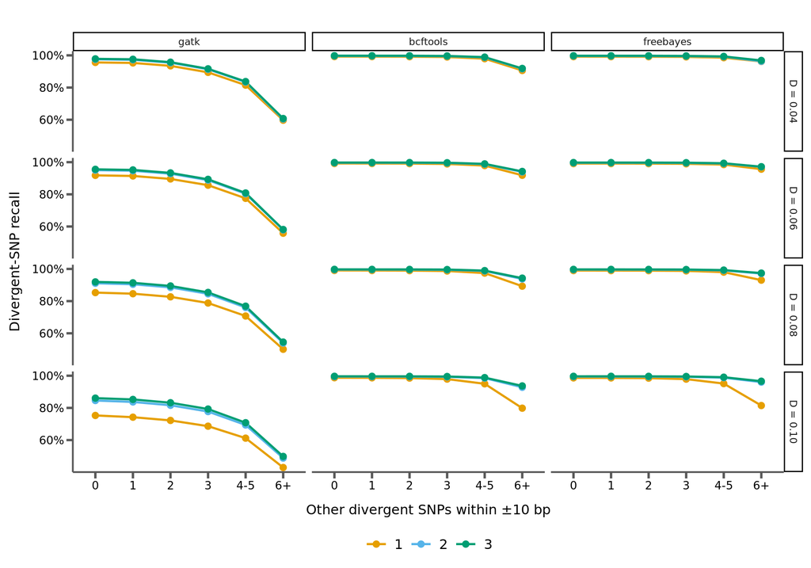

```r
MIN_SITES <- 100                                    # drop sparser bins (pooled over seeds)
CL_DIVS   <- c("0.04", "0.06", "0.08", "0.10")      # divergences shown in the figure
cl_bins   <- c("0", "1", "2", "3", "4-5", "6+")
cl <- read_csv("analyses/s01-baseline-iterative/results/cluster-recall/s01-cluster-recall-w10-w25.csv",
               col_types = cols(divergence = col_character(), n_near_bin = col_character())) %>%
  group_by(caller, divergence, iteration, window_bp, n_near_bin) %>%      # pool the seeds
  summarize(n_sites = sum(n_sites), n_recovered = sum(n_recovered), .groups = "drop") %>%
  filter(n_sites >= MIN_SITES) %>%
  mutate(recall = n_recovered / n_sites,
         caller = factor(caller, levels = c("gatk", "bcftools", "freebayes")),
         iteration = factor(iteration), n_near_bin = factor(n_near_bin, levels = cl_bins))
cl_r <- function(c, d, k, b, w = 10)                # one pooled recall, for the text below
  filter(cl, caller == c, divergence == d, iteration == k, n_near_bin == b, window_bp == w)$recall

ggplot(filter(cl, window_bp == 10, divergence %in% CL_DIVS),
       aes(x = n_near_bin, y = recall, color = iteration, group = iteration)) +
  geom_line(linewidth = 0.9) + geom_point(size = 2.4) +
  facet_grid(paste("D =", divergence) ~ caller) +
  scale_y_continuous(labels = scales::percent) +
  scale_color_manual(values = cols, name = "Iteration") +
  xlab("Other divergent SNPs within ±10 bp") + ylab("Divergent-SNP recall") +
  bartheme() + theme(legend.position = "bottom")
```

```r
filter(cl, window_bp == 25, divergence == "0.10", iteration %in% c("1", as.character(n_iter))) %>%
  transmute(caller, iteration, n_near_bin, recall = scales::percent(recall, accuracy = 0.1)) %>%
  pivot_wider(names_from = n_near_bin, values_from = recall) %>%
  arrange(caller, iteration) %>%
  kable(caption = "Recall at D = 0.10 by the number of other divergent SNPs within ±25 bp, iterations 1 and 3 (seeds pooled).",
        table.attr = 'class="center"')
```

Recall at D = 0.10 by the number of other divergent SNPs within ±25 bp, iterations 1 and 3 (seeds pooled).

| caller | iteration | 0 | 1 | 2 | 3 | 4-5 | 6+ |
| --- | --- | --- | --- | --- | --- | --- | --- |
| gatk | 1 | 91.0% | 84.5% | 79.2% | 75.5% | 71.7% | 65.7% |
| gatk | 3 | 93.8% | 91.6% | 88.5% | 86.0% | 82.7% | 76.5% |
| bcftools | 1 | 98.9% | 98.8% | 98.8% | 98.7% | 98.6% | 96.5% |
| bcftools | 3 | 99.7% | 99.7% | 99.7% | 99.6% | 99.6% | 99.2% |
| freebayes | 1 | 98.8% | 98.8% | 98.7% | 98.7% | 98.6% | 96.5% |
| freebayes | 3 | 99.7% | 99.7% | 99.7% | 99.6% | 99.6% | 99.3% |

**Interpretation.** GATK’s single-shot recall falls steadily as SNPs cluster, at every divergence: at D = 0.10 from 75% for SNPs with no other divergent SNP within ±10 bp to 43% for those with six or more, and already at D = 0.04 from 96% to 60%. bcftools and freebayes stay flat until the densest bin (there 80% and 81% at D = 0.10), and iteration repairs that bin for them (94% and 97% by iteration 3). Iteration lifts GATK in every bin but leaves the gap: at D = 0.10, iteration 3 recall is 50% in the densest bin against 86% for isolated SNPs. The same gradient appears at ±25 bp (table). This is the fixed-context, single-shot side of GATK’s failure; the neighbourhood analysis below shows the dynamic side (a SNP becomes callable once the unrecovered SNPs around it are written into the consensus).

## 3.6 Per-variant read fate: why a SNP is (not) called — whole chromosome

Everything above measures recovery in aggregate; this section asks, **per variant and directly at the reference base**, *why* each SNP is called or not — on **every** hom-div SNP on chr19 (no sampling; 2.46M sites at D=0.04 up to 6.14M at D=0.10). This is the project’s standard per-variant read-fate analysis (`analyses/lib/variant_read_fate.py`, run in `--aggregate` mode across all callers × divergences by `run_vrf_aggregate.sh`; figures rebuilt below from its summary tables).

**Definitions / assumptions.** For each true divergent SNP we take every read that *truly* covers its reference coordinate `p` and classify what that read does **at `p`**:

- **Covering reads** — reads whose *true* (mason-simulated) fragment spans `p`, assigned from the `-oa` truth BAM (i.e. from where the read came from, **not** where `bwa` put it) — so reads that were lost, mismapped, or unmapped are still counted in the denominator. A read’s true span is its interval on its source haplotype (`oP` tag, read length) mapped back to the reference, not the truth BAM’s alignment start/CIGAR (see Methods).
- **True allele via `oH`** — mason tags each read with its source haplotype (`oH`); with the phased genotype this gives each read’s *true* allele independent of sequencing error. For hom `1|1` SNPs both haplotypes carry the alt, so **`n_true_alt` = all covering reads** (verified exactly). (For a het `0|1` site — see s03 — the alt is on one haplotype, so `n_true_alt` is only the ~half of covering reads from that haplotype.)
- **`f_alt` = (reads with the alt aligned at `p`) / `n_true_alt`** — of the reads that *truly carry the alt*, the fraction that actually deliver it at the correct coordinate. A read whose *start* is shifted but whose SNP base still aligns at `p` counts (verified: shifted reads present the true alt, never a displaced base). It is **alt-support survival, not the pileup allele fraction**: the denominator is restricted to the alt-carrying reads, so `f_alt = 1` under unbiased mapping and drops below 1 only when those reads are lost (clipped / mismapped / unmapped). At a het site this means `f_alt` is ≈1 by construction unless the alt-haplotype reads drop out — it is *not* the ~0.5 you would get from ref+alt.
- **What is at `p`** (one class per covering read): `alt` / `ref` / `other-base (error)` aligned there; `clipped over p` / `deleted at p` (read at the locus but nothing aligned at `p`); `mapped elsewhere` / `unmapped` (read never reaches `p`). Read-start placement (exact/shifted) is deliberately collapsed — only what happens **at `p`** matters.

```r
library(ggalluvial)
AGG <- "analyses/s01-baseline-iterative/results/vrf-agg"        # aggregate tables from run_vrf_aggregate.sh
lv  <- c("gatk", "bcftools", "freebayes")
hcomp <- bind_rows(lapply(list.files(AGG, "hcomp.csv$", full.names = TRUE), read_csv, col_types = cols())) %>%
  mutate(caller = factor(caller, levels = lv))                  # per (caller,div,iter,call-status): at-p read-fate sums
gtraj <- bind_rows(lapply(list.files(AGG, "gtraj.csv$", full.names = TRUE), read_csv, col_types = cols()))
```

### 3.6.1 Why do SNPs stay uncalled?

For the SNPs a caller does **not** call, is the alt actually there (`alt maps at p`)? If yes, the caller — not the mapping — is the blocker.

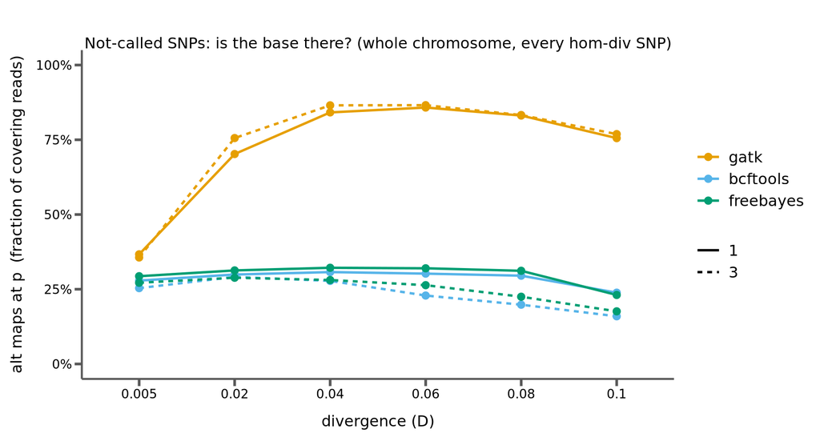

```r
hcomp %>% filter(status == "not_called", iteration %in% c(1, 3)) %>%
  mutate(alt_frac = alt_at_p / n_reads) %>%
  ggplot(aes(factor(divergence), alt_frac, color = caller, linetype = factor(iteration),
             group = interaction(caller, iteration))) +
  geom_line(linewidth = 0.9) + geom_point(size = 2.4) +
  scale_y_continuous(labels = scales::percent, limits = c(0, 1)) +
  scale_color_manual(values = corecol(pal = "wilke", numcol = 3), name = "caller") +
  scale_linetype_manual(values = c(`1` = "solid", `3` = "22"), name = "iteration") +
  labs(x = "divergence (D)", y = "alt maps at p  (fraction of covering reads)",
       title = "Not-called SNPs: is the base there? (whole chromosome, every hom-div SNP)") +
  bartheme()
```

### 3.6.2 What maps at position p (composition)

The full read-fate breakdown at the highest divergence (D=0.10), by caller (columns) and call outcome (rows). Read this at `p`: `alt maps at p` is the base being delivered; everything else is a way it isn’t.

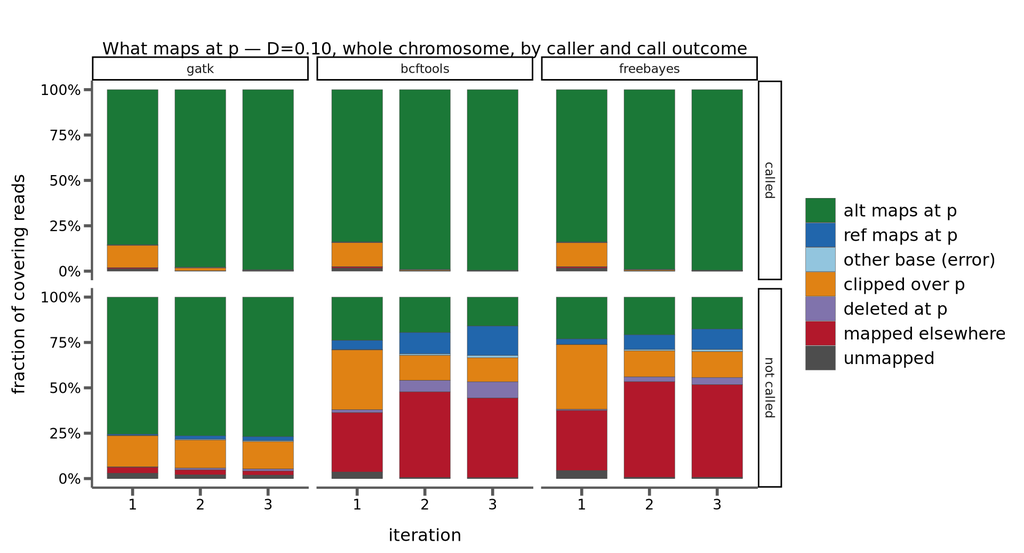

```r
cats <- c("alt_at_p", "ref_at_p", "err_at_p", "clipped", "deleted", "mapped_elsewhere", "unmapped")
nice <- c(alt_at_p = "alt maps at p", ref_at_p = "ref maps at p", err_at_p = "other base (error)",
          clipped = "clipped over p", deleted = "deleted at p",
          mapped_elsewhere = "mapped elsewhere", unmapped = "unmapped")
fcol <- setNames(c("#1b7837", "#2166ac", "#92c5de", "#e08214", "#8073ac", "#b2182b", "#4d4d4d"),
                 unname(nice[cats]))
hcomp %>% filter(divergence == 0.10) %>%
  pivot_longer(all_of(cats), names_to = "atp", values_to = "reads") %>%
  mutate(frac = reads / n_reads, atp = factor(nice[atp], levels = unname(nice[cats])),
         status = recode(status, called = "called", not_called = "not called")) %>%
  ggplot(aes(factor(iteration), frac, fill = atp)) +
  geom_col(width = 0.75, color = "grey30", linewidth = 0.12) + facet_grid(status ~ caller) +
  scale_fill_manual(values = fcol, name = "what is at position p") +
  scale_y_continuous(labels = scales::percent) +
  labs(x = "iteration", y = "fraction of covering reads",
       title = "What maps at p — D=0.10, whole chromosome, by caller and call outcome") +
  bartheme()
```

**Interpretation.** The *not-called* row is the story. gatk’s box is **green** (`alt maps at p`, ~76%) — the reads deliver the base. bcftools/freebayes are **red + orange** (`mapped elsewhere` ~40–53%, `clipped` ~15%) — the base isn’t presented, dominated by reads that mismapped or were clipped. Called SNPs converge to ~99.5% `alt maps at p` by iteration 3 for all three.

### 3.6.3 Joint state across iterations (G)

Each SNP flows through its joint (call status × `f_alt` bin) state per iteration. Within every panel the **lower box is `called`, the upper box `not called`** (thin gap between); colour bands are the `f_alt` bin (viridis; yellow = high, i.e. alt well-presented at `p`). Rows are callers, columns are divergence — all conditions, whole chromosome. (Larger single-condition versions, with the box labels, are also written to `results/vrf-viz-full/G_<caller>_D<div>.png`.)

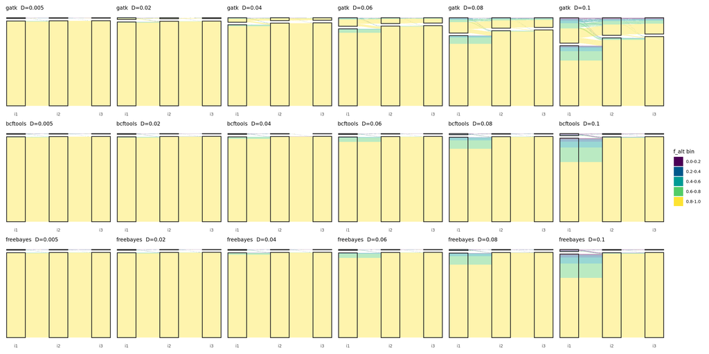

```r
BIN   <- c("0.0-0.2", "0.2-0.4", "0.4-0.6", "0.6-0.8", "0.8-1.0")
fbcol <- setNames(hcl.colors(5, "Viridis"), BIN)
Glev  <- c(paste("not called", BIN, sep = " · "), "gap", paste("called", BIN, sep = " · "))
makeG <- function(cc, dd, showlab = TRUE) {
  g <- gtraj %>% filter(caller == cc, divergence == dd, fb1 %in% BIN, fb2 %in% BIN, fb3 %in% BIN)
  lodes <- g %>% mutate(id = row_number()) %>%
    pivot_longer(c(s1, fb1, s2, fb2, s3, fb3), names_to = c(".value", "iter"),
                 names_pattern = "([a-z]+)([0-9])") %>%
    transmute(id, n = n_snps, iter, status = ifelse(s == "not_called", "not called", "called"),
              fb = factor(fb, levels = BIN),
              state = factor(paste(status, fb, sep = " · "), levels = Glev), is_gap = FALSE)
  gapN <- round(0.03 * sum(g$n_snps))
  lodes <- bind_rows(lodes, tibble(id = max(lodes$id) + 1, n = gapN, iter = c("1", "2", "3"),
                     status = "gap", fb = factor(NA, levels = BIN),
                     state = factor("gap", levels = Glev), is_gap = TRUE))
  box <- lodes %>% filter(!is_gap) %>% group_by(iter, status) %>% summarize(n = sum(n), .groups = "drop") %>%
    group_by(iter) %>% mutate(ncall = sum(n[status == "called"])) %>% ungroup() %>%
    mutate(pos = as.integer(iter), xmin = pos - 0.22, xmax = pos + 0.22,
           ymin = ifelse(status == "called", 0, ncall + gapN),
           ymax = ifelse(status == "called", ncall, ncall + gapN + n), yc = (ymin + ymax) / 2)
  p <- ggplot(lodes, aes(x = iter, stratum = state, alluvium = id, y = n, fill = fb, alpha = is_gap)) +
    geom_flow() +
    geom_rect(data = box, aes(xmin = xmin, xmax = xmax, ymin = ymin, ymax = ymax), inherit.aes = FALSE, fill = "white") +
    geom_stratum(color = NA, width = 0.44) +
    geom_rect(data = box, aes(xmin = xmin, xmax = xmax, ymin = ymin, ymax = ymax), inherit.aes = FALSE, fill = NA, color = "grey15", linewidth = 0.6)
  if (showlab)
    p <- p + geom_text(data = box, aes(x = pos, y = yc, label = status), inherit.aes = FALSE, size = 2.5, fontface = "bold", colour = "grey10")
  p + scale_alpha_manual(values = c(`FALSE` = 0.4, `TRUE` = 0), guide = "none") +
    scale_fill_manual(values = fbcol, name = "f_alt bin", na.value = "white", na.translate = FALSE) +
    scale_x_discrete(labels = c("i1", "i2", "i3"), expand = c(0.08, 0.08)) +
    labs(x = NULL, y = NULL, title = sprintf("%s  D=%s", cc, format(dd))) +
    theme_minimal(base_size = 9) + theme(panel.grid = element_blank(), axis.text.y = element_blank(),
                                         plot.title = element_text(size = 9))
}
conds <- expand.grid(dd = c(0.005, 0.02, 0.04, 0.06, 0.08, 0.10), cc = lv, stringsAsFactors = FALSE)  # rows=caller, cols=div
patchwork::wrap_plots(Map(function(cc, dd) makeG(cc, dd, showlab = FALSE), conds$cc, conds$dd),
                      ncol = 6, guides = "collect")
```

**Interpretation.** The caller split is visible in every column: gatk’s `not called` box (upper) carries a big **yellow** (high `f_alt`) band at all divergences — base present, uncalled (assembler ceiling) — whereas bcftools/freebayes `not called` boxes are the **low bins** (base absent, alignment-limited), and that low-bin mass grows with divergence. All three `called` boxes (lower) fill toward yellow across iterations as placement tidies. Divergence runs left→right: the not-called block grows and its `f_alt` structure shifts down for the pileup/haplotype callers, while gatk’s stays high.

**Data dictionary — `results/vrf-agg/vrf-agg-<caller>-<div>-{gtraj,hcomp}.csv`.** Aggregate summaries over the whole chromosome; no per-SNP rows are stored.

- `-hcomp.csv` — one row per (`divergence`, `caller`, `iteration`, `status`∈{called,not_called}). Columns `alt_at_p, ref_at_p, err_at_p, clipped, deleted, mapped_elsewhere, unmapped` are **read counts** summed over all SNPs (what maps at `p`); `n_reads` is their total (all covering reads). Fractions = column / `n_reads`.
- `-gtraj.csv` — one row per distinct 3-iteration trajectory of (`s{k}`=call status, `fb{k}`=`f_alt` bin) with `n_snps` = number of SNPs that followed it. `f_alt` bins are 0.2-wide (`0.0-0.2` … `0.8-1.0`); `s{k}` ∈ {called, not_called}. Feeds figure G.

### 3.6.4 Companion decomposition: what changes when a SNP flips to called?

`f_alt` is one-dimensional — alt-support survival — and by construction blind to the *reference / contaminant* reads at `p`, the depth, and the MAPQ. So when a SNP flips not-called→called we ask what *else* moved. We re-run the read-fate tool in `--pileup` mode on a 30k-SNP sample (`run_vrf_pileup.sh`), which adds the **position-centric pileup at `p`** — the caller’s-eye view of every read aligned over `p` — **and two complementary mismap counts**: **mismapped-IN** (`mmin_*`: reads aligned at `p` whose *true* span is elsewhere — foreign reads the ledger books at their home loci) and its corollary **mismapped-OUT** (reads that *belong* at `p` by truth but are mapped elsewhere or unmapped, `mm_clip+mm_noclip+dc+un`). We join consecutive iterations per SNP and compare the pileup across **three fates** — `not-called→called` (flip), `called→called` (stayed called), `not-called→not-called` (stayed not-called) — over **all `f_alt` bins** and **all divergences**, tracking depth, ref reads, mismapped-in, mismapped-out, MAPQ, and `f_alt`. The by-divergence and by-fate figures pool **all SNPs** in a group; only the last figure separates by `f_alt` bin.

```r
PILE  <- "analyses/s01-baseline-iterative/results/vrf-pileup"
BINS  <- c("0.0-0.2", "0.2-0.4", "0.4-0.6", "0.6-0.8", "0.8-1.0")
FATES <- c("stayed not-called", "flip (→called)", "stayed called")
nbps <- read_csv("analyses/s01-baseline-iterative/results/neighborhood/neighborhood-per-snp.csv",
                 col_types = cols())                         # per-SNP unrecovered-neighbor load
pl <- bind_rows(lapply(list.files(PILE, "vrf-pileup-.*\\.csv$", full.names = TRUE),
                       read_csv, col_types = cols())) %>%
  left_join(select(nbps, caller, divergence, snp_pos, iteration, nb_unrec = n_unrecovered),
            by = c("caller", "divergence", "snp_pos", "iteration")) %>%
  mutate(caller = factor(caller, levels = c("gatk", "bcftools", "freebayes")),
         f_alt = ifelse(n_true_alt > 0, (ex_alt + sh_alt) / n_true_alt, NA_real_),
         called = recovered == 1)
mkpairs <- function(k) inner_join(filter(pl, iteration == k), filter(pl, iteration == k + 1),
                                  by = c("caller", "divergence", "snp_pos"), suffix = c("_a", "_b"))
pairs <- bind_rows(mkpairs(1), mkpairs(2)) %>%
  filter(!is.na(f_alt_a), !is.na(f_alt_b)) %>%
  mutate(grp = case_when(!called_a &  called_b ~ "flip (→called)",
                          called_a &  called_b ~ "stayed called",
                         !called_a & !called_b ~ "stayed not-called",
                          TRUE ~ "lost (called→not)"),
         grp = factor(grp, levels = FATES),
         fbin_a = cut(f_alt_a, breaks = seq(0, 1, 0.2), include.lowest = TRUE, labels = BINS),
         # mismapped-OUT: reads whose TRUE span covers p but are mapped elsewhere/unmapped -- the
         # mirror of mismapped-in (foreign reads AT p). From the truth-centric ledger cells.
         mmout_a = mm_clip_a + mm_noclip_a + dc_a + un_a,
         mmout_b = mm_clip_b + mm_noclip_b + dc_b + un_b)
flip <- filter(pairs, grp == "flip (→called)")

# per-SNP distribution boxplots by fate, for one divergence (depth included; a SEPARATE figure per D
# rather than another facet dimension, which would be too busy)
METS <- c("depth at p", "f_alt", "ref reads at p", "mismapped-in ref", "mismapped-out",
          "mean MAPQ at p", "neighbor unrec SNPs (±200bp)")
distfig <- function(dd) {
  d1 <- filter(pairs, grp %in% FATES, divergence == dd) %>% mutate(id = row_number())
  bind_rows(
    d1 %>% transmute(id, caller, grp, metric = "depth at p",       before = depth_p_a,   after = depth_p_b),
    d1 %>% transmute(id, caller, grp, metric = "f_alt",            before = f_alt_a,      after = f_alt_b),
    d1 %>% transmute(id, caller, grp, metric = "ref reads at p",   before = ref_p_a,      after = ref_p_b),
    d1 %>% transmute(id, caller, grp, metric = "mismapped-in ref", before = mmin_ref_p_a, after = mmin_ref_p_b),
    d1 %>% transmute(id, caller, grp, metric = "mismapped-out",    before = mmout_a,      after = mmout_b),
    d1 %>% transmute(id, caller, grp, metric = "mean MAPQ at p",   before = mapq_p_a,     after = mapq_p_b),
    d1 %>% transmute(id, caller, grp, metric = "neighbor unrec SNPs (±200bp)", before = nb_unrec_a, after = nb_unrec_b)) %>%
    pivot_longer(c(before, after), names_to = "state", values_to = "value") %>%
    mutate(state = factor(state, levels = c("before", "after")), metric = factor(metric, levels = METS)) %>%
    ggplot(aes(state, value, fill = caller)) +
    geom_boxplot(outlier.size = 0.2, outlier.alpha = 0.2, linewidth = 0.28,
                 position = position_dodge(0.8), width = 0.7) +
    facet_grid(metric ~ grp, scales = "free_y") +
    scale_fill_manual(values = corecol(pal = "wilke", numcol = 3), name = "caller") +
    labs(x = "earlier → later iteration", y = NULL,
         title = sprintf("Per-SNP pileup DISTRIBUTIONS by fate — s01, D=%s", format(dd))) +
    bartheme() +
    theme(strip.text.y = element_text(angle = 0), panel.spacing = unit(0.85, "lines"),
          panel.border = element_rect(color = "grey75", fill = NA, linewidth = 0.4),
          strip.background = element_rect(fill = "grey92", color = "grey75", linewidth = 0.4))
}

# mean trend across divergences for ONE fate (a compact direction-of-change view; one figure per fate)
labA <- c(depth = "depth at p", ref = "ref reads at p", mminref = "mismapped-in ref",
          mmout = "mismapped-out", mapq = "mean MAPQ at p", falt = "f_alt",
          nbunrec = "neighbor unrec SNPs (±200bp)")
meantrend <- function(g) {
  filter(pairs, grp == g) %>% group_by(caller, divergence) %>%
    summarize(depth_a = mean(depth_p_a), depth_b = mean(depth_p_b), ref_a = mean(ref_p_a), ref_b = mean(ref_p_b),
              mminref_a = mean(mmin_ref_p_a), mminref_b = mean(mmin_ref_p_b),
              mmout_a = mean(mmout_a), mmout_b = mean(mmout_b), mapq_a = mean(mapq_p_a), mapq_b = mean(mapq_p_b),
              falt_a = mean(f_alt_a), falt_b = mean(f_alt_b),
              nbunrec_a = mean(nb_unrec_a), nbunrec_b = mean(nb_unrec_b), .groups = "drop") %>%
    pivot_longer(matches("_(a|b)$"), names_pattern = "(.+)_([ab])$", names_to = c("metric", ".value")) %>%
    mutate(metric = factor(labA[metric], levels = unname(labA))) %>%
    pivot_longer(c(a, b), names_to = "state", values_to = "value") %>%
    mutate(state = factor(ifelse(state == "a", "earlier", "later"), levels = c("earlier", "later"))) %>%
    ggplot(aes(state, value, group = caller, color = caller)) +
    geom_line(linewidth = 0.85) + geom_point(size = 2.2) +
    facet_grid(metric ~ divergence, scales = "free_y", labeller = labeller(divergence = label_both)) +
    scale_color_manual(values = corecol(pal = "wilke", numcol = 3), name = "caller") +
    labs(x = NULL, y = "group mean", title = sprintf("MEAN pileup by divergence — %s", g)) +
    bartheme() +
    theme(strip.text.y = element_text(angle = 0), panel.spacing = unit(1, "lines"),
          panel.border = element_rect(color = "grey75", fill = NA, linewidth = 0.4),
          strip.background = element_rect(fill = "grey92", color = "grey75", linewidth = 0.4))
}
```

**Per-SNP distributions** (boxplots, not means), one figure **per divergence** for the three fates. Each box is the spread of that pileup axis over all SNPs in the fate at the earlier vs later iteration; the median line and IQR show how wide the variation really is behind any single mean. `depth at p` is included and is roughly flat across the flip — foreign reads leave *as* the true reads arrive.

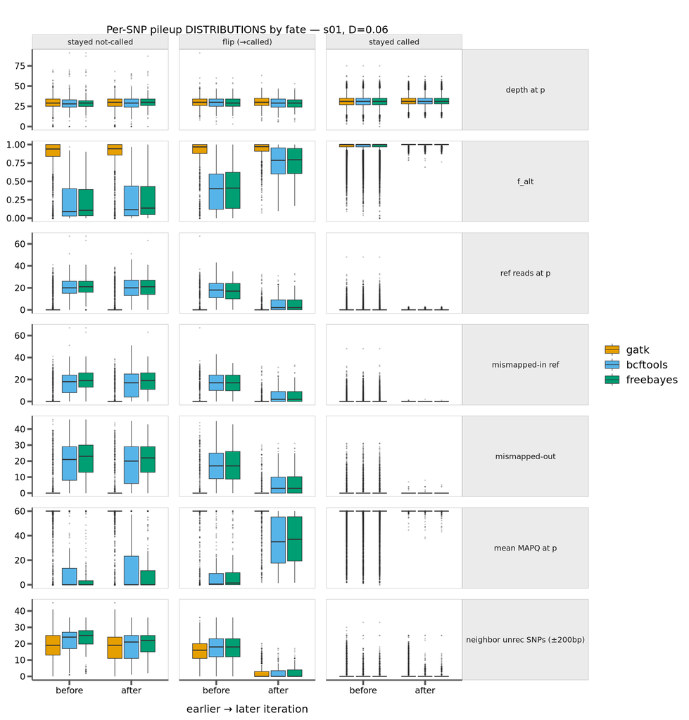

```r
distfig(0.06)
```

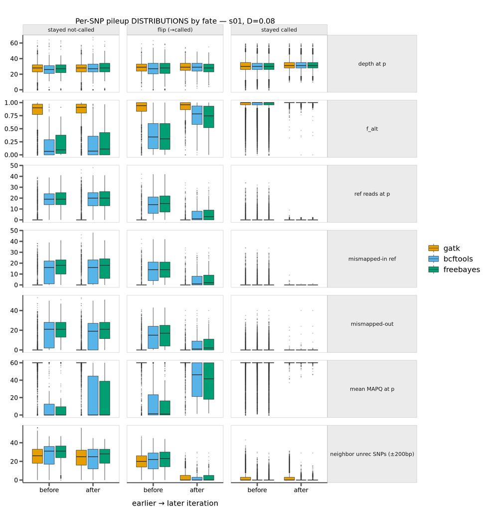

```r
distfig(0.08)
```

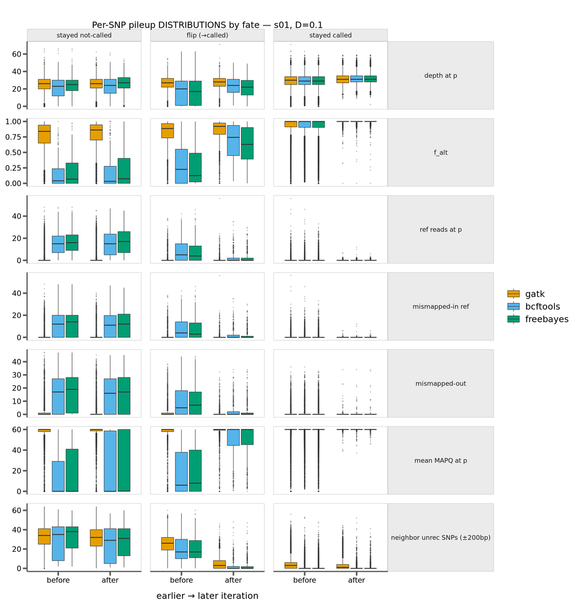

```r
distfig(0.10)
```

The **mean trend across divergences**, one figure per fate — the compact direction-of-change view (each point a group mean; the boxplots above show the spread). In **flips** every contamination axis falls while `f_alt`/MAPQ rise; **stayed called** is flat and clean at every divergence; **stayed not-called** stays contaminated throughout — the sites iteration cannot fix.

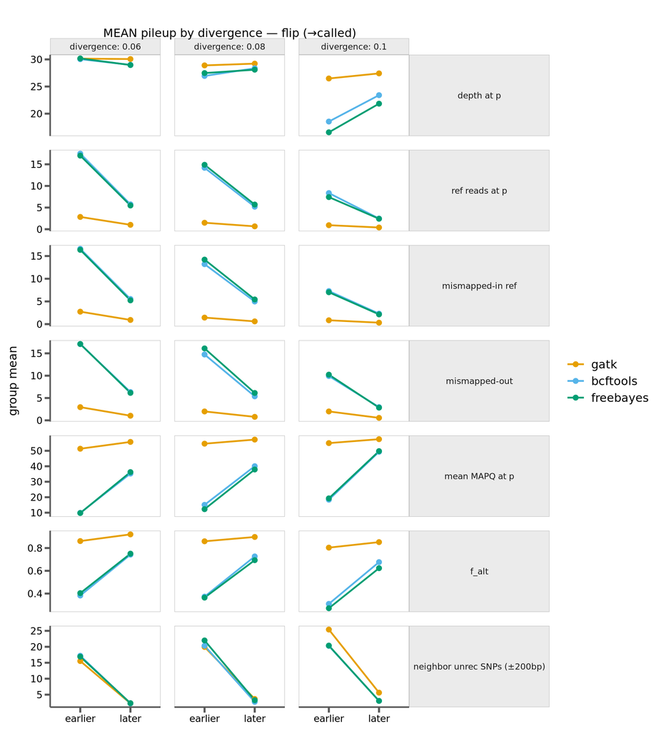

```r
meantrend("flip (→called)")
```

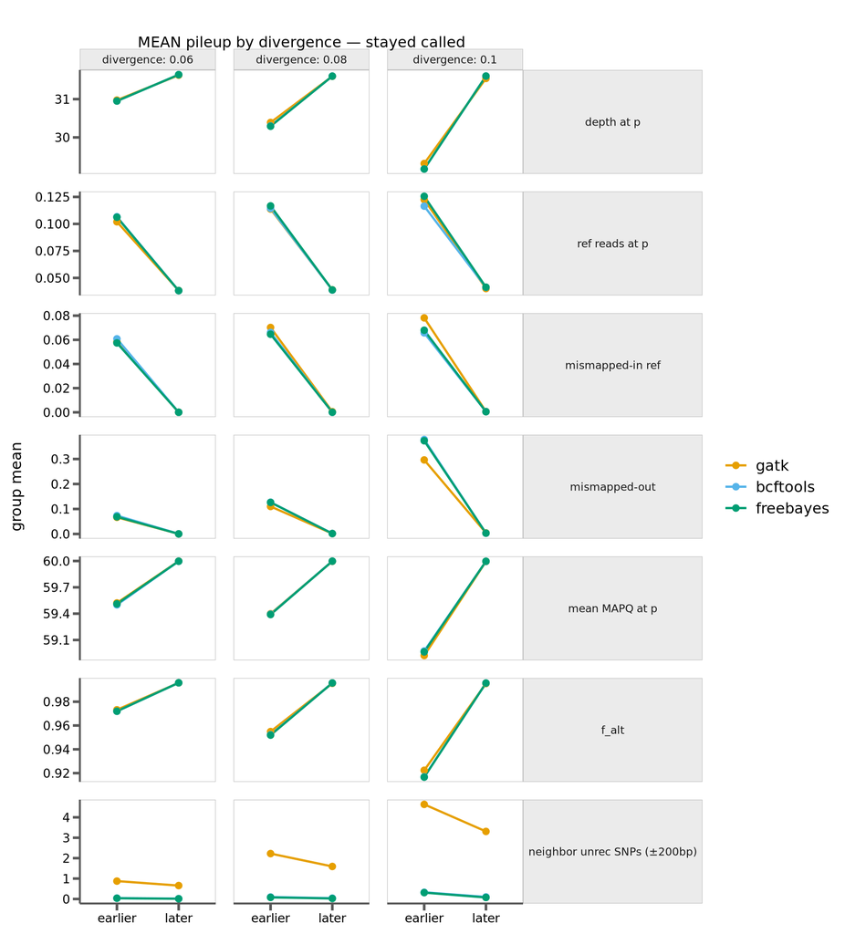

```r
meantrend("stayed called")
```

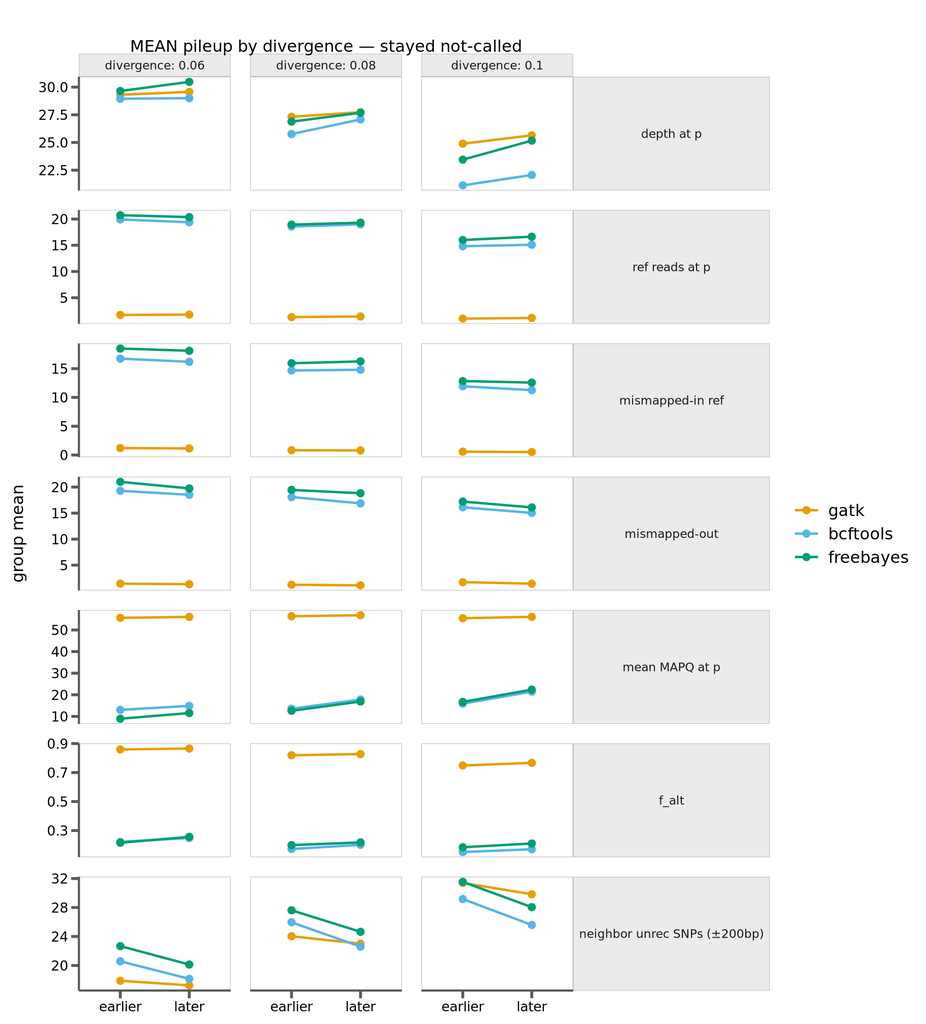

```r
meantrend("stayed not-called")
```

Finally, the flips by **starting `f_alt` bin** (D=0.10, group means). Left: `f_alt` before vs after — the top bin is flat while low bins **migrate up** (alt support re-anchors). Right: the mismapped-in ref contamination that clears, present in every bin.

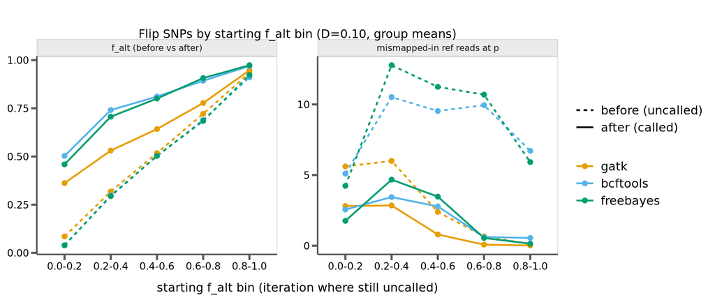

```r
labB <- c(falt = "f_alt (before vs after)", mminref = "mismapped-in ref reads at p")
flip %>% filter(divergence == 0.10) %>% group_by(caller, fbin_a) %>%
  summarize(falt_a = mean(f_alt_a), falt_b = mean(f_alt_b),
            mminref_a = mean(mmin_ref_p_a), mminref_b = mean(mmin_ref_p_b), .groups = "drop") %>%
  pivot_longer(c(falt_a, falt_b, mminref_a, mminref_b),
               names_pattern = "(.+)_([ab])$", names_to = c("metric", ".value")) %>%
  mutate(metric = factor(labB[metric], levels = unname(labB))) %>%
  pivot_longer(c(a, b), names_to = "state", values_to = "value") %>%
  mutate(state = factor(ifelse(state == "a", "before (uncalled)", "after (called)"),
                        levels = c("before (uncalled)", "after (called)"))) %>%
  ggplot(aes(fbin_a, value, color = caller, linetype = state, group = interaction(caller, state))) +
  geom_line(linewidth = 0.85) + geom_point(size = 2.1) +
  facet_wrap(~ metric, scales = "free_y") +
  scale_color_manual(values = corecol(pal = "wilke", numcol = 3), name = "caller") +
  scale_linetype_manual(values = c("before (uncalled)" = "22", "after (called)" = "solid"), name = NULL) +
  labs(x = "starting f_alt bin (iteration where still uncalled)", y = NULL,
       title = "Flip SNPs by starting f_alt bin (D=0.10, group means)") +
  bartheme() +
  theme(panel.spacing = unit(1.4, "lines"),
        panel.border = element_rect(color = "grey75", fill = NA, linewidth = 0.4),
        strip.background = element_rect(fill = "grey92", color = "grey75", linewidth = 0.4))
```

#### 3.6.4.1 The gatk signature: flips with an unchanged pileup

The most striking pattern is **gatk**: almost nothing about the pileup at `p` changes when a gatk SNP flips to called. Two ways to see it (D=0.10). First, how often the pileup was *already* clean before the flip (clean = `f_alt≥0.8`, `≤2` ref reads, `MAPQ≥50`, `≤2` mismapped-in — indistinguishable from a called site):

```r
pairs %>% filter(divergence == 0.10, grp == "flip (→called)") %>%
  mutate(already_clean = f_alt_a >= 0.8 & ref_p_a <= 2 & mapq_p_a >= 50 & mmin_ref_p_a <= 2) %>%
  group_by(caller) %>%
  summarize(`n flips` = n(),
            `pileup already clean before flip` = sprintf("%.0f%%", 100 * mean(already_clean)),
            .groups = "drop") %>%
  kable(caption = "Fraction of flip SNPs whose pileup at p already looked called-ready before the flip.",
        table.attr = 'class="center"')
```

Fraction of flip SNPs whose pileup at p already looked called-ready before the flip.

| caller | n flips | pileup already clean before flip |
| --- | --- | --- |
| gatk | 3174 | 65% |
| bcftools | 509 | 1% |
| freebayes | 530 | 1% |

Second, how much each axis actually moves across the flip (mean absolute change):

```r
pairs %>% filter(divergence == 0.10, grp == "flip (→called)") %>%
  group_by(caller) %>%
  summarize(`Δ depth` = round(mean(abs(depth_p_b - depth_p_a)), 1),
            `Δ ref` = round(mean(abs(ref_p_b - ref_p_a)), 1),
            `Δ mismap-in` = round(mean(abs(mmin_ref_p_b - mmin_ref_p_a)), 1),
            `Δ MAPQ` = round(mean(abs(mapq_p_b - mapq_p_a)), 1),
            `Δ f_alt` = round(mean(abs(f_alt_b - f_alt_a)), 2), .groups = "drop") %>%
  kable(caption = "Mean absolute change in each pileup axis across the flip.",
        table.attr = 'class="center"')
```

Mean absolute change in each pileup axis across the flip.

| caller | Δ depth | Δ ref | Δ mismap-in | Δ MAPQ | Δ f_alt |
| --- | --- | --- | --- | --- | --- |
| gatk | 1.4 | 0.6 | 0.6 | 2.6 | 0.05 |
| bcftools | 9.4 | 6.3 | 5.3 | 31.0 | 0.37 |
| freebayes | 9.5 | 5.5 | 5.1 | 30.6 | 0.35 |

For **~65% of gatk flips the pileup at `p` is already clean before the flip** and barely moves (MAPQ shifts ~2.6, `f_alt` ~0.05) — versus ~1% for the pileup callers, whose flips move everything (MAPQ ~31, `f_alt` ~0.37). gatk is *not* freed by a better pileup at the SNP; its reads were presentable all along. Recovery must come from **off `p`** — the reference-anchored reassembler finally closing the local haplotype once the surrounding consensus has converged, a change invisible to any at-`p` measurement (quantified next).

#### 3.6.4.2 What changes off p: the local unrecovered-SNP load

If the change is in the neighborhood, we can measure it. For each SNP we count the **other true hom-div SNPs within ±200 bp** (roughly HaplotypeCaller’s active-region + assembly window) that are **not yet recovered** into the consensus at that iteration — the local mismatch load the reference-anchored reassembler must bridge to find shared exact k-mers and close a haplotype (`analyses/lib/neighborhood_assembly.py` via `run_neighborhood.sh`, `results/neighborhood/`).

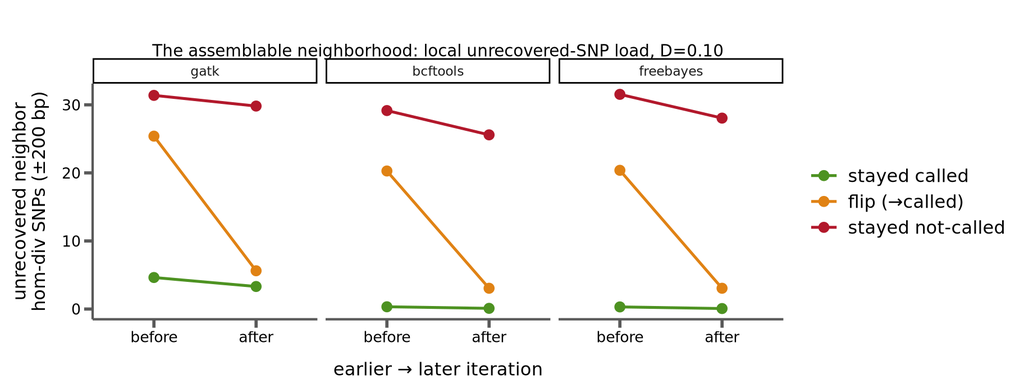

```r
nb <- read_csv("analyses/s01-baseline-iterative/results/neighborhood/neighborhood-summary.csv",
               col_types = cols())
fcol <- c("stayed called" = "#4d9221", "flip (→called)" = "#e08214", "stayed not-called" = "#b2182b")
nb %>% filter(divergence == 0.10, fate %in% c("flip", "stayed_notcalled", "stayed_called")) %>%
  transmute(caller = factor(caller, levels = c("gatk", "bcftools", "freebayes")),
            fate = factor(fate, levels = c("stayed_called", "flip", "stayed_notcalled"),
                          labels = names(fcol)),
            before = mean_unrecovered_before, after = mean_unrecovered_after) %>%
  pivot_longer(c(before, after), names_to = "state", values_to = "unrec") %>%
  mutate(state = factor(state, levels = c("before", "after"))) %>%
  ggplot(aes(state, unrec, color = fate, group = fate)) +
  geom_line(linewidth = 0.9) + geom_point(size = 2.8) +
  facet_wrap(~ caller) +
  scale_color_manual(values = fcol, name = "fate") +
  labs(x = "earlier → later iteration", y = "unrecovered neighbor\nhom-div SNPs (±200 bp)",
       title = "The assemblable neighborhood: local unrecovered-SNP load, D=0.10") +
  bartheme() + theme(plot.title = element_text(size = 11))
```

**This is the answer.** For **flips** the local unrecovered-SNP load **collapses** — gatk 25→6 at D=0.10 — into the range where already-called sites live (~4), while **stayed-not-called** neighborhoods stay cluttered (31→30) and never assemble, which is exactly why they never flip. The *same* collapse drives the pileup callers’ flips (20→3): the common upstream cause is the **local consensus converging**, which lowers the neighborhood’s divergence to the reference. It simply acts through a different bottleneck — **assembly** for gatk (whose reads at `p` were already presentable), **read placement** for bcftools/freebayes (letting the contaminating reads at `p` map to their true homes). One cause, two effects — the assembler-vs-alignment split, measured directly.

**Interpretation.** First the caution the distributions make plain (Figure 1): these groups are strongly **right-skewed**, so means overstate the typical SNP — the bcftools flip group *averages* ~8 ref reads at D=0.10 but the **median flip SNP has 5 (IQR 0–15)**, and many start with none. With that in mind the **three fates** separate cleanly:

- **stayed called** (the large control): clean at both iterations — ~0 ref reads, `f_alt`≈1. These were never contaminated; nothing needs to change.
- **flip (→called)**: contaminated → clean. Ref reads at `p` clear (median 5→0) and, in lockstep, the **mismapped-out** reads that *belong* at `p` come home (5→0) — the SNP’s own reads return as the foreign ref reads leave, and MAPQ rises. The ref reads are almost entirely **mismapped-in** (foreign): the mismapped-in count tracks the ref count nearly one-to-one.
- **stayed not-called**: the contamination **persists** — ref reads stay ~15, mismapped-out stays ~17, `f_alt` stays ≈0 across the iteration. These are the genuinely hard sites (repetitive / multi-mapping neighborhoods) the consensus can’t disentangle, which is *why* they never flip.

*Note on the `f_alt≈0` not-called band:* these are not unsimulated sites. Every truth SNP is present in its reads (truth check, Methods), so `f_alt≈0` means the reads that carry the alt did not arrive at the site (lost, mismapped or clipped): a mapping loss, not a missing allele.

# 4 Heterozygous site recovery

Het sites (true `0/1`) are the classic allelic-dropout target of reference bias: when a het’s alt-bearing reads map poorly, the site looks homozygous-reference. They are never baked into the (haploid) consensus, so this is scored from the **raw per-iteration caller VCF** vs truth — `het_tp / n_truth_het`.

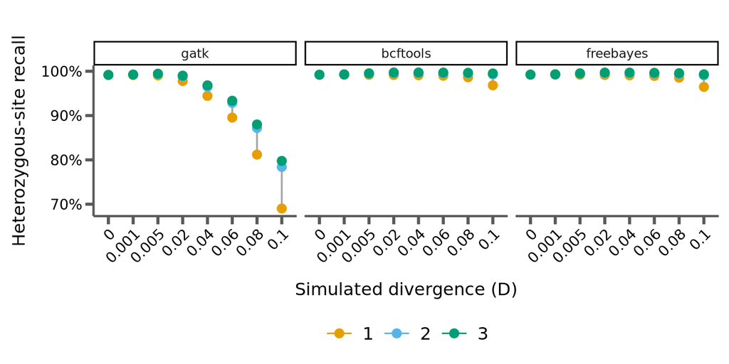

```r
ggplot(hets, aes(x = factor(divergence), y = m, color = iteration)) +
  geom_line(aes(group = divergence), color = "grey65", size = 0.6) +
  geom_errorbar(aes(ymin = m - s, ymax = m + s), width = 0.0015) +
  geom_point(size = 2.6) +
  facet_wrap(~caller) +
  scale_x_discrete(guide = guide_axis(angle = 45)) +
  scale_y_continuous(labels = scales::percent) +
  scale_color_manual(values = cols, name = "Iteration") +
  xlab("Simulated divergence (D)") + ylab("Heterozygous-site recall") +
  bartheme() + theme(legend.position = "bottom")
```

**Interpretation.** Het recall behaves almost exactly like the divergence recall — same caller ordering, same iteration rescue, and per caller the two nearly coincide (at D=0.10 single-shot: gatk het 69% vs div 70%; bcftools het 97% vs div 98%). So het reference bias is **not** a uniform evidence effect. It splits into (1) a **small, caller-independent allelic-dropout tax** — the pileup callers sit ~1 point below their own divergence recall (99.2% → ~97% as D rises), the genuine case where a het’s alt reads are clipped/unmapped; iteration restores it; and (2) a **large, gatk-specific loss that mirrors its homozygous divergence deficit** — het sites in divergent regions are missed by the same reassembly failure that loses the homozygous divergent SNPs, and recovered the same way as effective divergence falls. For the assembler, a het in a divergent window is lost for the same reason a homozygous divergent SNP is.

# 5 Summary

- **Iterative mapping recovers more true divergence** — recall rises every iteration and converges by ~3 rounds.
- **The benefit is largest where single-shot is weakest**: negligible for the pileup/ haplotype callers already near ceiling, but a large lift for gatk at high divergence (single-shot 70.4% → iterated 81.0% at D=0.10; 3 seeds, SD <0.1 pt). The fate bars show the same thing as a shrinking “lost to reference” band.
- **Heterozygous sites recover the same way**: het recall closely tracks divergence recall per caller (gatk ~69%→80% at D=0.10; pileup callers ~97%→99.5%), so het reference bias is dominated by the same assembler mechanism — plus a small caller-independent allelic-dropout tax that iteration also restores.
- **This is a caller, not a mapping, effect**: single-shot read placement is caller-independent (identical iter1 bars), yet gatk recovers the fewest SNPs — so its deficit is the reference-anchored assembler. As the consensus converges, reads map more exactly (gatk soft-clip 40%→10% at D=0.10), a readout of falling effective divergence that both tracks and feeds the recovery.

*Scope: chr19, SNP-only, 30×. Open question: how far does iteration go — does recall plateau below 100%, and is the residual the repeat/mapping-limited floor? (Test with more iterations + a convergence diagnostic.) Indels + liftover are s02.*